# Spatial Correction of Field Trial Data Using GAMM

### Summary across all examples

```r
summary_df <- data.frame(
  Scenario = c(
    "Ex1: Uniform gradient — per-bench",
    "Ex1: Uniform gradient — pooled",
    "Ex2: Mixed patterns   — per-bench",
    "Ex2: Mixed patterns   — pooled"
  ),
  Pearson_r_raw  = round(c(cor_raw,     cor_raw,        cor_raw_ex2,   cor_raw_ex2),   3),
  Pearson_r_BLUP = round(c(cor_blup,    cor_pooled_ex1, cor_blup_ex2,  cor_pooled_ex2), 3),
  stringsAsFactors = FALSE
)
print(summary_df, row.names = FALSE)
```

```
##                           Scenario Pearson_r_raw Pearson_r_BLUP
##  Ex1: Uniform gradient — per-bench         0.944          0.979
##     Ex1: Uniform gradient — pooled         0.944          0.984
##  Ex2: Mixed patterns   — per-bench         0.932          0.958
##     Ex2: Mixed patterns   — pooled         0.932          0.974
```

## Should we loop over benches?

### The problem with per-bench looping

The default pipeline fits a **separate model for each bench** and then averages the per-bench BLUPs:

$$\hat{g}_k^{\text{per-bench}} =
\frac{1}{n_b} \sum_{l=1}^{n_b}
\bigl(\hat{\mu}_l + \hat{u}_{k|l}\bigr)$$

This is a **simple average**, not a mixed-model BLUP. It has three statistical weaknesses:

1. **Variance components estimated independently per bench.** The genotype variance $\sigma_g^2$ is re-estimated from scratch on each bench’s ~150 observations. Estimates are noisy, and are not shared across benches even though the same genotypes are observed on all benches.
2. **No genotype × bench interaction (GEI) component.** A single model across benches can decompose the variance into $\sigma_g^2$ (stable genotype main effect) and $\sigma_{gb}^2$ (genotype–bench interaction). The per-bench loop conflates these, producing BLUPs that are mixtures of both.
3. **No formal cross-bench shrinkage.** If a genotype’s observation is missing or an outlier on one bench, its cross-bench mean BLUP is pulled toward that bench’s data equally. In a proper joint model, the missing bench contributes nothing and the BLUP borrows only from the benches that have data.

### The joint multi-bench model

The statistically appropriate model for a multi-bench unreplicated trial pools all benches in a single REML fit:

$$y_{ijkl} = \mu + \beta_l + f_l(r_i, c_j)
+ g_k + \rho_{il} + \kappa_{jl}
+ \varepsilon_{ijkl}$$

| Term | Meaning |
| --- | --- |
| $\beta_l$ | Bench fixed effect (absorbs between-bench mean differences) |
| $f_l(r, c)$ | Bench-specific spatial surface — separate `te()` per bench via `by = Bench` |
| $g_k \sim N(0, \sigma_g^2)$ | Genotype random effect estimated jointly across all benches |
| $\rho_{il}, \kappa_{jl}$ | Bench-specific row / column random effects |

The critical improvement is that **$\sigma_g^2$ is estimated from all bench data simultaneously**, and each genotype BLUP is shrunk toward the grand mean using the pooled estimate. The `te(Row, Col, by = Bench)` term allows completely different spatial surfaces per bench — identical flexibility to separate models — but within a single likelihood.

**When bench as random is preferred.** If benches are drawn from a population (e.g. multiple glasshouse experiments in different years), bench can be treated as a random effect: $\beta_l \sim N(0, \sigma_b^2)$. This makes BLUPs portable to unobserved benches but requires removing the parametric bench term, which complicates smooth identification. For a fixed, known set of benches (e.g. a single experiment), the fixed-bench formulation above is appropriate and avoids this complication.

**A note on GEI in unreplicated designs.** With exactly 1 replicate per genotype per bench, the genotype × bench interaction $\sigma_{gb}^2$ is confounded with residual error $\sigma^2$. Including a `s(Genotype, Bench, bs="re")` interaction term will cause the residual to collapse to zero. For unreplicated designs, it is better to omit GEI and acknowledge that $\hat{g}_k$ captures the average genotype effect across benches — variation in rank across benches is absorbed into the residual.

### Implementation: joint multi-bench GAM via `mgcv::gam()`

We use `mgcv::gam()` with `bs = "re"` smooths for random effects (the “GAMM via GAM” approach, Wood 2017 §6.6). This keeps all computations in the `mgcv` package without calling `nlme` or `lme4`.

```r
#' Fit joint multi-bench GAM with bench-specific spatial smooths
#' @param dfr       full data frame (all benches)
#' @param pheno     response column name
#' @param gt        genotype column name
#' @param rn        row column name
#' @param cn        column column name
#' @param bench_col bench column name
#' @param k_dims    integer vector c(k_row, k_col)
#' @return gam() object
fit_gam_multibench <- function(dfr, pheno, gt, rn, cn, bench_col, k_dims) {
  dfr$bench_rowf   <- as.factor(paste0(dfr[[bench_col]], "_r", dfr[[rn]]))
  dfr$bench_colf   <- as.factor(paste0(dfr[[bench_col]], "_c", dfr[[cn]]))
  dfr[[bench_col]] <- as.factor(dfr[[bench_col]])
  dfr[[gt]]        <- as.factor(dfr[[gt]])

  # te(Row, Col, by=Bench): separate P-spline surface per bench
  # + Bench (fixed): required for smooth identifiability with factor by-variable
  # s(Genotype, bs="re"): genotype random intercept — estimated jointly
  # s(bench_rowf/colf, bs="re"): bench-specific row/col random intercepts
  formula_str <- paste0(
    pheno, " ~ ", bench_col,
    " + te(", rn, ", ", cn, ", by=", bench_col,
    ", bs=c('ps','ps'), k=c(", k_dims[1], ",", k_dims[2], "))",
    " + s(", gt, ", bs='re')",
    " + s(bench_rowf, bs='re') + s(bench_colf, bs='re')"
  )
  gam(as.formula(formula_str), data = dfr, method = "REML")
}

#' Extract genotype BLUPs from a joint multi-bench GAM
#' @param model     gam() object from fit_gam_multibench()
#' @param dfr       data frame used for fitting
#' @param gt        genotype column name
#' @param bench_col bench column name
#' @return data.frame: Genotype, predicted
extract_blups_gam_mb <- function(model, dfr, gt, bench_col) {
  # predict(type="terms") gives the contribution of each smooth/parametric
  # term per observation.  The genotype smooth s(gt) is a random intercept:
  # its value is the same for every observation belonging to the same genotype.
  terms_mat <- predict(model, type = "terms")
  gt_col_nm <- paste0("s(", gt, ")")
  gt_re     <- terms_mat[, gt_col_nm]

  # Average over plots per genotype (all values identical for a given genotype)
  geno_re <- tapply(gt_re, dfr[[gt]], mean)

  # Grand mean: parametric intercept + mean bench fixed effect
  fe        <- coef(model)[!grepl("^s\\(", names(coef(model)))]
  intercept <- as.numeric(fe["(Intercept)"])
  bench_fe  <- fe[grepl(paste0("^", bench_col), names(fe))]
  grand_mean <- intercept + mean(c(0, as.numeric(bench_fe)))

  data.frame(
    Genotype  = names(geno_re),
    predicted = grand_mean + as.numeric(geno_re),
    stringsAsFactors = FALSE
  )
}
```

```r
k_dims_mb <- auto_k_dims(sim1$data[sim1$data$Bench == "Bench1", ], "Row", "Col")

model_mb <- fit_gam_multibench(
  dfr       = sim1$data,
  pheno     = "BNI",
  gt        = "Genotype",
  rn        = "Row",
  cn        = "Col",
  bench_col = "Bench",
  k_dims    = k_dims_mb
)

# Brief model summary — effective degrees of freedom for each term
cat("k_dims:", k_dims_mb, "\n")
```

```
## k_dims: 5 7
```

```r
cat("Terms and EDF:\n")
```

```
## Terms and EDF:
```

```r
print(round(summary(model_mb)$edf, 2))
```

```
## [1]   6.53   5.70   5.55   6.04 144.70   7.28  20.21
```

```r
cat("Total EDF:", round(sum(model_mb$edf), 1), "\n")
```

```
## Total EDF: 200
```

```r
blups_mb <- extract_blups_gam_mb(model_mb, sim1$data, "Genotype", "Bench")

# Compare directly to true effects
comp_mb <- merge(blups_mb, sim1$true_effects, by = "Genotype")
cor_mb  <- cor(comp_mb$predicted, comp_mb$True_BNI)

cat(sprintf("Joint multi-bench GAM — BLUP r vs true: %.3f\n", cor_mb))
```

```
## Joint multi-bench GAM — BLUP r vs true: 0.983
```

```r
cat(sprintf("Per-bench GAMM (loop)  — BLUP r vs true: %.3f\n", cor_blup))
```

```
## Per-bench GAMM (loop)  — BLUP r vs true: 0.979
```

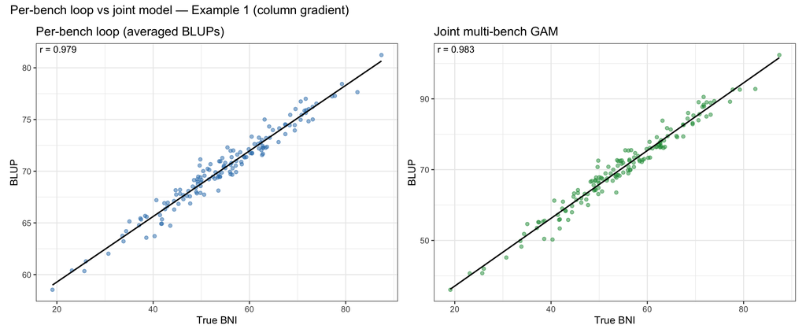

```r
# Merge per-bench and joint BLUPs for side-by-side scatter
comp_both <- merge(mean_blups_ex1, blups_mb, by = "Genotype") %>%
  inner_join(sim1$true_effects, by = "Genotype")

p_loop <- ggplot(comp_both, aes(x = True_BNI, y = BNI_BLUP_mean)) +
  geom_point(alpha = 0.5, size = 1.5, colour = "#2c7bb6") +
  geom_smooth(method = "lm", se = FALSE, colour = "black", linewidth = 0.7) +
  annotate("text", x = -Inf, y = Inf, hjust = -0.1, vjust = 1.4, size = 3.5,
           label = sprintf("r = %.3f", cor_blup)) +
  labs(title = "Per-bench loop (averaged BLUPs)",
       x = "True BNI", y = "BLUP") +
  theme_bw()

p_joint <- ggplot(comp_both, aes(x = True_BNI, y = predicted)) +
  geom_point(alpha = 0.5, size = 1.5, colour = "#1a9641") +
  geom_smooth(method = "lm", se = FALSE, colour = "black", linewidth = 0.7) +
  annotate("text", x = -Inf, y = Inf, hjust = -0.1, vjust = 1.4, size = 3.5,
           label = sprintf("r = %.3f", cor_mb)) +
  labs(title = "Joint multi-bench GAM",
       x = "True BNI", y = "BLUP") +
  theme_bw()

p_loop + p_joint +
  plot_annotation(title = "Per-bench loop vs joint model — Example 1 (column gradient)")
```

The joint model is expected to produce marginally better or equal recovery. For a well-controlled glasshouse trial the two approaches typically agree closely, since σ²_g is reasonably stable across benches. In field trials or multi-year experiments with large GEI, the joint model will show a clearer advantage.

## Comparison with SpATS

### Background

**SpATS** (Spatial Analysis of Trials with Splines; Rodriguez-Alvarez et al. 2018) fits a similar P-spline spatial correction model to the GAMM, using an efficient REML algorithm based on the SAP (Smoothing and P-splines) framework. The main structural differences are:

| Feature | GAMM (`mgcv`) | SpATS |
| --- | --- | --- |
| Spatial surface | `te(row, col, bs=c("ps","ps"))` | `SAP(col, row)` or `PSANOVA(col, row)` |
| Random effects | `nlme::lme()` / `bs="re"` | Internal REML (Henderson equations) |
| Multi-bench | Separate models or joint via `by=` | Typically per-bench; no native joint model |
| BLUP output | `ranef()` / `predict(type="terms")` | `predict(model, which=gt)` |
| Spatial plot | Manual via `plot_smooth_heatmap()` | `plot(model)` — built-in |

SpATS is specifically designed for this application and tends to be faster per bench. The GAMM approach is more flexible (arbitrary random effects, multi-bench pooling, richer diagnostics).

### SpATS per-bench fitting

```r
has_spats <- requireNamespace("SpATS", quietly = TRUE)
if (!has_spats) message("SpATS not installed — install.packages('SpATS') to run this section.")
```

```r
#' Fit SpATS model for one bench, returning genotype BLUPs and spatial trend
#' @param bench_data  single-bench data frame
#' @param pheno       response column name
#' @param gt          genotype column name
#' @param rn          row column name
#' @param cn          column column name
#' @param k_row       approximate row complexity (nseg_row = max(4, k_row-1))
#' @param k_col       approximate col complexity (nseg_col = max(4, k_col-1))
#' @return list with $blups (Genotype, predicted, se) and
#'         $plot_data (Row, Col, Fitted, SpatialTrend)
run_spats_bench <- function(bench_data, pheno, gt, rn, cn, k_row, k_col) {
  if (!requireNamespace("SpATS", quietly = TRUE))
    stop("SpATS package required")

  d        <- bench_data
  d$rn_var <- d[[rn]]
  d$cn_var <- d[[cn]]
  d$rnf    <- as.factor(d$rn_var)
  d$cnf    <- as.factor(d$cn_var)
  d[[gt]]  <- as.factor(d[[gt]])

  n_seg_col <- max(4L, as.integer(k_col) - 1L)
  n_seg_row <- max(4L, as.integer(k_row) - 1L)

  invisible(capture.output(
    spatD <- SpATS::SpATS(
      response           = pheno,
      spatial            = ~ SpATS::SAP(cn_var, rn_var,
                                         nseg = c(n_seg_col, n_seg_row)),
      genotype           = gt,
      genotype.as.random = TRUE,
      random             = ~ rnf + cnf,
      data               = d,
      control            = list(tolerance = 1e-04, monitoring = 0)
    )
  ))

  geno_pred <- SpATS::predict.SpATS(spatD, which = gt)

  # Spatial trend = fitted values minus the per-plot genotype BLUP, centred
  geno_blup_vec <- geno_pred$predicted.values[
    match(as.character(d[[gt]]), as.character(geno_pred[[gt]]))]
  spatial_raw   <- spatD$fitted - geno_blup_vec
  spatial_trend <- spatial_raw - mean(spatial_raw, na.rm = TRUE)

  list(
    blups = data.frame(
      Genotype  = as.character(geno_pred[[gt]]),
      predicted = geno_pred$predicted.values,
      se        = geno_pred$standard.errors,
      stringsAsFactors = FALSE
    ),
    plot_data = data.frame(
      Row          = d[[rn]],
      Col          = d[[cn]],
      Fitted       = spatD$fitted,
      SpatialTrend = spatial_trend,
      stringsAsFactors = FALSE
    )
  )
}
```

```r
# Fit SpATS on Example 1 (uniform gradient) — all 4 benches
k_s1 <- auto_k_dims(sim1$data[sim1$data$Bench == "Bench1", ], "Row", "Col")

spats_ex1 <- lapply(unique(sim1$data$Bench), function(b) {
  bd  <- sim1$data[sim1$data$Bench == b, ]
  res <- tryCatch(
    run_spats_bench(bd, "BNI", "Genotype", "Row", "Col", k_s1[1], k_s1[2]),
    error = function(e) { message("SpATS Ex1 bench ", b, ": ", e$message); NULL }
  )
  if (is.null(res)) return(NULL)
  res$blups$Bench     <- b
  res$plot_data$Bench <- b
  res
})
spats_ex1 <- Filter(Negate(is.null), spats_ex1)

spats_blups_ex1  <- do.call(rbind, lapply(spats_ex1, `[[`, "blups"))
spats_plots_ex1  <- do.call(rbind, lapply(spats_ex1, `[[`, "plot_data"))
spats_means_ex1  <- spats_blups_ex1 %>%
  group_by(Genotype) %>%
  summarise(BNI_SpATS = mean(predicted, na.rm = TRUE), .groups = "drop")

# Fit SpATS on Example 2 (mixed patterns) — all 4 benches
k_s2 <- auto_k_dims(sim2_data[sim2_data$Bench == "Bench_Grad1", ], "Row", "Col")

spats_ex2 <- lapply(unique(sim2_data$Bench), function(b) {
  bd  <- sim2_data[sim2_data$Bench == b, ]
  res <- tryCatch(
    run_spats_bench(bd, "BNI", "Genotype", "Row", "Col", k_s2[1], k_s2[2]),
    error = function(e) { message("SpATS Ex2 bench ", b, ": ", e$message); NULL }
  )
  if (is.null(res)) return(NULL)
  res$blups$Bench     <- b
  res$plot_data$Bench <- b
  res
})
spats_ex2 <- Filter(Negate(is.null), spats_ex2)

spats_blups_ex2 <- do.call(rbind, lapply(spats_ex2, `[[`, "blups"))
spats_plots_ex2 <- do.call(rbind, lapply(spats_ex2, `[[`, "plot_data"))
spats_means_ex2 <- spats_blups_ex2 %>%
  group_by(Genotype) %>%
  summarise(BNI_SpATS = mean(predicted, na.rm = TRUE), .groups = "drop")

cat("SpATS: Ex1 BLUPs for", nrow(spats_means_ex1), "genotypes,",
    "Ex2 BLUPs for", nrow(spats_means_ex2), "genotypes\n")
```

```
## SpATS: Ex1 BLUPs for 150 genotypes, Ex2 BLUPs for 150 genotypes
```

## GAMM vs SpATS comparison

### Spatial surface comparison — Example 1, one bench

The most direct way to compare the two methods is to visualise what each fitted as the spatial trend for the same bench. Both use P-spline surfaces; minor differences reflect algorithm choices (GAMM via `nlme` REML vs SpATS SAP).

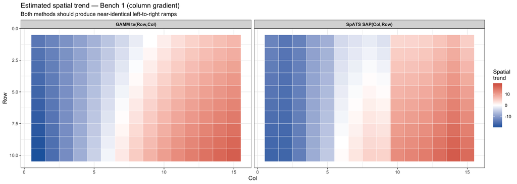

```r
# Extract GAMM spatial trend for Bench1
gamm_trend_b1 <- fitted_ex1[fitted_ex1$Bench == "Bench1",
                              c("row", "col", "BNI_SpatialTrend")]
names(gamm_trend_b1) <- c("Row", "Col", "SpatialTrend")
gamm_trend_b1$Method <- "GAMM te(Row,Col)"

# SpATS spatial trend for Bench1
spats_trend_b1 <- spats_plots_ex1[spats_plots_ex1$Bench == "Bench1",
                                    c("Row", "Col", "SpatialTrend")]
spats_trend_b1$Method <- "SpATS SAP(Col,Row)"

surf_both <- rbind(gamm_trend_b1, spats_trend_b1)
lim_surf  <- max(abs(surf_both$SpatialTrend), na.rm = TRUE)

ggplot(surf_both, aes(x = Col, y = Row, fill = SpatialTrend)) +
  geom_tile(colour = "white", linewidth = 0.2) +
  scale_fill_gradientn(
    colours = c("#2166ac", "white", "#d6604d"),
    limits  = c(-lim_surf, lim_surf),
    name    = "Spatial\ntrend"
  ) +
  scale_y_reverse() +
  facet_wrap(~ Method) +
  labs(title = "Estimated spatial trend — Bench 1 (column gradient)",
       subtitle = "Both methods should produce near-identical left-to-right ramps") +
  theme_bw() +
  theme(strip.text = element_text(face = "bold"))
```

### BLUP agreement — do the two methods rank genotypes the same way?

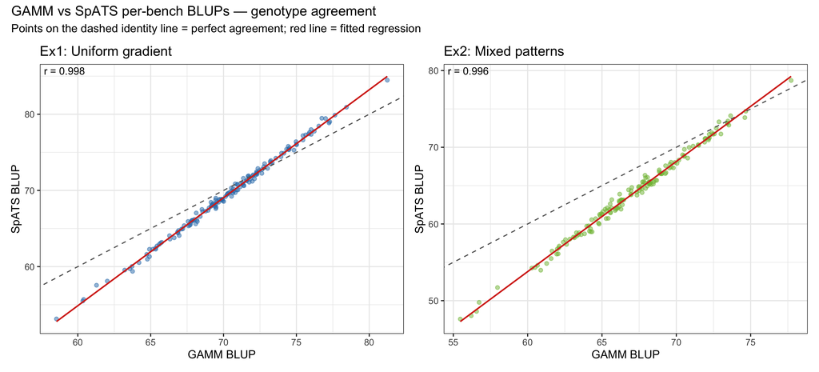

```r
# Combine per-bench GAMM and SpATS BLUPs for Example 1
agree_ex1 <- mean_blups_ex1 %>%
  rename(GAMM = BNI_BLUP_mean) %>%
  inner_join(rename(spats_means_ex1, SpATS = BNI_SpATS), by = "Genotype")

r_agree_ex1 <- round(cor(agree_ex1$GAMM, agree_ex1$SpATS), 3)

# Same for Example 2
agree_ex2 <- mean_blups_ex2 %>%
  rename(GAMM = BNI_BLUP_mean) %>%
  inner_join(rename(spats_means_ex2, SpATS = BNI_SpATS), by = "Genotype")

r_agree_ex2 <- round(cor(agree_ex2$GAMM, agree_ex2$SpATS), 3)

p_ag1 <- ggplot(agree_ex1, aes(x = GAMM, y = SpATS)) +
  geom_point(alpha = 0.5, size = 1.5, colour = "#2c7bb6") +
  geom_abline(slope = 1, intercept = 0, linetype = "dashed", colour = "grey40") +
  geom_smooth(method = "lm", se = FALSE, colour = "#d7301f", linewidth = 0.7) +
  annotate("text", x = -Inf, y = Inf, hjust = -0.1, vjust = 1.4, size = 3.5,
           label = paste0("r = ", r_agree_ex1)) +
  labs(title = "Ex1: Uniform gradient",
       x = "GAMM BLUP", y = "SpATS BLUP") +
  theme_bw()

p_ag2 <- ggplot(agree_ex2, aes(x = GAMM, y = SpATS)) +
  geom_point(alpha = 0.5, size = 1.5, colour = "#7fbc41") +
  geom_abline(slope = 1, intercept = 0, linetype = "dashed", colour = "grey40") +
  geom_smooth(method = "lm", se = FALSE, colour = "#d7301f", linewidth = 0.7) +
  annotate("text", x = -Inf, y = Inf, hjust = -0.1, vjust = 1.4, size = 3.5,
           label = paste0("r = ", r_agree_ex2)) +
  labs(title = "Ex2: Mixed patterns",
       x = "GAMM BLUP", y = "SpATS BLUP") +
  theme_bw()

(p_ag1 + p_ag2) +
  plot_annotation(
    title    = "GAMM vs SpATS per-bench BLUPs — genotype agreement",
    subtitle = "Points on the dashed identity line = perfect agreement; red line = fitted regression"
  )
```